# M3 Assignment

The goal of this assignment will be to construct the best model for classifying if a tweet is generated by an AI or real.

**Loading packages**

```r
rm(list = ls()) # Clearing the environment
options(scipen=999) # No scientific notations
library(tidyverse)
library(tidymodels)
library(tidytext)
library(magrittr)
library(recipes)
library(textrecipes)
library(keras)
library(jsonlite)
```

## Data preparation

*Loading the data*

```r
data_raw <- read_json("m3 assignment/data/trump_vs_GPT2.json")
```

The raw data is a json file, thus the data_raw object is a list. This list consists of two categories, where the first contains all the tweets, and the second is a boolean which indicates whether the Trump tweet is false, i.e. AI generated tweets, or true if they were written by Donald Trump. As I find it nicer to work with, I convert the list into a tibble, using *as_tibble*. This resulted in a nested tibble, as the data contained a list of dataframes. I turn it into a regular tibble by using *unnest*.

```r
data <- as_tibble(data_raw) %>%
  unnest(cols = c(`0`, `1`)) %>% # Unnesting the tibble, and specifying the columns to be 0 and 1.
  set_colnames(c("tweet", "by_trump")) # Renaming the columns.
```

To inspect the data I print 5 authentic and 5 generated tweets.

```r
data %>%
  group_by(by_trump) %>%
  slice(1:5)
```

| tweet | by_trump |
| --- | --- |
| #ThankYou #CharlotteCaucus was thrilled to be back in the Great city of Charlotte, North Carolina with thousands of hardworking American Patriots who love our Country, cherish our laws, and always put… | FALSE |
| No Obstruction! new study by Dr. Bruce Ohr on the Great Debate Performance. Congratulations to @DrBruceohr on his amazing study on the Debate Performance. | FALSE |
| Fake News Media seems to do everything they can to disparage President Trump. That doesn’t make any sense!” @marklevinshow @foxandfriendsFake News Media is the Enemy of the People and the Enemy of the… | FALSE |
| Thank you! FIVETH ANNIVERSARY to our great citizens! you to the people of South Carolina! Now I have the courage to demand unity and a fair vote in November - a great day for our Country! Birthday! ht… | FALSE |
| I’ve just watched Democrats scream over and over again about trying to Impeach the President of the United States. The Impeachment process is a sham. | FALSE |
| I was thrilled to be back in the Great city of Charlotte, North Carolina with thousands of hardworking American Patriots who love our Country, cherish our values, respect our laws, and always put AMER… | TRUE |
| The Unsolicited Mail In Ballot Scam is a major threat to our Democracy, &amp; the Democrats know it. | TRUE |
| As long as I am President, I will always stand with the HEROES of Law Enforcement! | TRUE |
| Our Economy is doing great, and is ready to set new records - best ever (Again!). | TRUE |
| If I do not sound like a typical Washington politician, it’s because I’m NOT a politician. | TRUE |

The fake tweets do not really stand out too much, and are generally very well made. However, in this small inspection there are some randomly ending sentences, odd misspellings and strange capitalization of words in the AI generated tweets. These are however not unlikely to be seen from Donald Trumps actual tweets. Some of the tweets contain the html representation of &, making amp a top word. However, it is possible that the generated tweets have a tendency to use these in a distinct manner, which could help the model classification, and I will therefore not be removing them.

Next I will take a look at the top words. To do this I tokenize the words in the tweets.

```r
data %>%
  unnest_tokens(word,tweet) %>% #Tokenizing the tweets.
  count(word, sort = TRUE) # Sorting by descending order.
```

| word | n |
| --- | --- |
| the | 23438 |
| to | 12483 |
| and | 11277 |
| of | 9055 |
| a | 8340 |
| in | 6730 |
| is | 6246 |
| for | 5445 |
| i | 4293 |
| our | 4118 |

[output cut: 9990 more lines]

Clearly the stopwords are very dominant in the tweets. This would have been a problem if one were to apply a bag-of-words model, since the importance of the words would be misleading. However as I am intending on looking at the words in their context, i.e. looking at sequential data, the stopwords carry more meaning. When inspecting top words, they do however not provide too much insight, which is why I remove them from the table. This is done by anti-joining with a lexicon of stop words, such as *stop_words* which comes with **tidy_text**. To make the table a bit more relevant I compare the top words for the fake tweets and the real tweets.

```r
data %>%
  unnest_tokens(word, tweet) %>%
  anti_join(stop_words, by = 'word') %>% # Removing stopwords.
  filter(!(word == "amp")) %>% # Removing amp manually, since it is technically a stopword.
  group_by(by_trump) %>% # Grouping by "by_trump" to count the classes seperately.
  count(word, sort = TRUE) %>%
  slice(1:10)
```

| by_trump | word | n |
| --- | --- | --- |
| FALSE | people | 1299 |
| FALSE | democrats | 1013 |
| FALSE | country | 1001 |
| FALSE | news | 976 |
| FALSE | fake | 944 |
| FALSE | president | 934 |
| FALSE | trump | 629 |
| FALSE | job | 590 |
| FALSE | american | 588 |
| FALSE | maga | 563 |

[output cut: 10 more lines]

The AI seems to have a more limited vocabulary, or atleast repeat more of the same topics, since the top words generally have a higher count, even though there are an equal amount of real and fake tweets. Other than that, many of the top words are the same. Since the AI uses a lot of the same words as the real Donald Trump, a bag-of-words representation would most likely not be very helpful in distinguishing real or fake tweets.

## Preprocessing

The data needs preprocessing such that it can be used in neural networks. The first thing I do, is to split the dataset in training and testing subsamples. I use 75% of the data to train my models and evaluate them using the remaining 25%. As I want an equal amount of real and fake tweets in the training, as well as the testing data, I simply use *initial_split*, with the argument *strata*, to create random samples with equal ratios of real and fake tweets.

```r
set.seed(1337)
data_split <- initial_split(data, prop = 0.75, strata = by_trump) # Stratifying the splits using y, meaning the splits maintain the distribution of y.
data_train <- data_split  %>%  training() # Defining the training data-split.
data_test <- data_split %>% testing() # Defining the test data-split.
```

Next task is to create the tensor representation of the data. The goal will be to represent the tweets in a matrix, where each tweet has it’s own row, columns represent the word position in the tweet and each word has a unique integer representation. To begin this task I want to tokenize the tweets, such that each word in a tweet is a token. There are many ways to do this, but since I also want to create sequences of my tokens, such that my models can recognize that a sequence of words belongs to the same tweet, I use the *text_tokenizer* from **keras**. This step deals with all the remaining cleaning of the data through the arguments in the *text_tokenizer* function. First I chose the number of words I want the models to deal with, through *num_words*. The default here is all words, which would result in 15631 unique words in the training and test data. I chose to restrict this to 6000 words, since model performance was not improved by having less common words in the tweets, which would suggest the additional words were superfluous. Next I remove unwanted elements from tokens by the *filters* argument. Since I will not be going in depth with natural language processing, I am just using the default filter, to remove most of the unwanted elements. Another issue to address is the capitalization of characters in the tweets. While the AI might be using capitalization in odd manners, handling the words in a case-sensitive manner, will explode the word count. Furthermore, trying to explain the differences in the capitalization, if these are distinguishable, will most likely be difficult to explain. I opt for the simple solution to convert every character to lowercase, through the *lower* argument.

The tokenizer function needs to be fitted to the training and test data, to update its internal storage, whereby, for instance, the words that are unique in the test data are added to the word index made from the training data. This is important when it has to consider which words to keep, w.r.t. the *num_words* argument. I define the preprocessing function.

```r
tokenizer <- text_tokenizer(num_words = 6000, # Only keeping the most common 2000 words.
                            filters = "!\"#$%&™()*+,-./:;<=>?@[\\]^_`{|}~\t\n", # Filtering the listed elements from tokens.
                            lower = TRUE, # Lowering all characters.
                            split = " ", # Defining character/string to use for splitting tokens.
                            char_level = FALSE, # If true every character will be treated as a token.
                            oov_token = TRUE) # Replacing out of vocabulary words.
```

Next I fit the tokenizer to the training data.

```r
fit_text_tokenizer(tokenizer, data_train$tweet)
```

With the vocabulary of the tokenizer updated, I can represent the tweets by sequences of integers through *texts_to_sequences*.

```r
data_token_training <- texts_to_sequences(tokenizer, data_train$tweet)
```

Every tweet is now represented as a sequence of integers. For instance, the original tweet was:

```r
data_train[4,]
```

| tweet | by_trump |
| --- | --- |
| Our Economy is doing great, and is ready to set new records - best ever (Again!). | TRUE |

Which has been converted to:

```r
data_token_training[4]
```

```
## [[1]]
##  [1]   11  140    8   76   13    4    8  514    3  991   60 1352  231  163  137
```

This provides a much better reading experience for the neural networks. Let’s check the word index.

```r
tokenizer$index_word %>%
  as_tibble() %>% # Converting to a tibble with one word in each column.
  ncol() # Counting the number of columns in the tibble.
```

```
## [1] 13492
```

```r
fit_text_tokenizer(tokenizer, data_test$tweet)
data_token_test <- texts_to_sequences(tokenizer, data_test$tweet)
```

Let’s see if it worked.

```r
tokenizer$word_index %>%
  as_tibble() %>%
  ncol()
```

```
## [1] 15631
```

The vocabulary has been updated to 15631 words, however the model input will still only use the top 6000 words, which should reduce the noise a bit, while still conveying the general meaning of the sequences. The next step is to create a homogenous input for the models, i.e. the final tensor representation of the dataset, which is accomplished using the *pad_sequences* function. Here it is important that the tweets have the same dimensions, which is solved by finding the tweet containing the most words, and converting all other tweets to an equal length, by adding 0’s before the first integer. A problem can arise if the max length is very high, since this would create a matrix with a lot of columns. This can’t be a problem with this dataset, since tweets maximally can contain 280 characters, including whitespaces, which makes it impossible to create a tweet containing more than 140 words.

```r
x_train <- pad_sequences(data_token_training)
x_train %>% glimpse()
```

```
##  num [1:11052, 1:65] 0 0 0 0 0 0 0 0 0 0 ...
```

Not specifying a max length resulted in a matrix with 65 columns. The test data might not have a tweet of similar length, so in order to ensure equal lengths of the two matrices I specify a max length for the test data (this would have otherwise resulted in a 60 column matrix instead of 65).

```r
x_test <- pad_sequences(data_token_test, maxlen = 65)
x_test %>% glimpse()
```

```
##  num [1:3684, 1:65] 0 0 0 0 0 0 0 0 0 0 ...
```

Great now the two tensors are of equal widths. Next I create the output vector, by converting the logicals to numeric values, with 1 representing true and 0 representing false.

```r
y_train <- data_train$by_trump %>%
  as.numeric() # Converting the logicals to numeric values.
y_test <- data_test$by_trump %>%
  as.numeric()

y_train %>% glimpse()
```

```
##  num [1:11052] 1 1 1 1 1 1 1 1 1 1 ...
```

The output labels for the training have the same length as the training dataset, which is also the case for the testing data. The data is now ready to be used to train and test the models.

## Model building

### RNN

My first model will be a recurrent neural network (RNN). As mentioned previously, the words used are similar in the two classes, and it is therefore necessary to consider the context of the words, when trying to distinguish between the classes. This requires the model to have memory about the previous words. Within RNN’s this is solved by including loops and state variables, which hold information about the previous iteration of the loop.

The first layer of my RNN is an embedding layer, which will be training to find co-occurrences in the sequential data, to attempt to create analogies between documents, and hopefully get a better understanding of what is important in each tweet. Since the layer is trainable, it can be used to make the model more efficient. The input to the embedding layer needs to be equal or higher than the data the model will be fit on, to not go out of bounds, which is 6000, as the vocabulary is restricted to the most common 6000 words. I specify the output dimensions to be 32, meaning that every word will be represented by 32 dimensions. The word embeddings are used by my RNN layer, which has 65 neurons. The neurons use the hyperbolic tangent activation function, “tanh”, which is recommended for RNN layers. Activated connections are passed along to the final dense layer, which uses a sigmoid activation function to output a final prediction. The purpose of the model is to see how an parsimonious RNN performs on the data, to use as a baseline for my other models.

```r
set.seed(1337)
model_rnn1 <- keras_model_sequential() %>%
  layer_embedding(input_dim = 6000, output_dim =  32) %>%
  layer_simple_rnn(units = 65, activation = "tanh") %>%
  layer_dense(units = 1, activation = "sigmoid")
```

Next I compile the model. Here I have to specify an optimization algorithm, a loss function and a metric to measure performance. Since it is a binary classification problem i use binary-crossentropy, and since the classes are balanced I evaluate my models using accuracy. I will not be changing the compiler function for my different models, as the problem type will remain the same throughout.

```r
set.seed(1337)
model_rnn1 %>% compile(optimizer = "adam",
                      loss = "binary_crossentropy",
                      metrics = "accuracy")
```

Let’s have a look at the model.

```r
summary(model_rnn1)
```

```
## Model: "sequential"
## ________________________________________________________________________________
## Layer (type)                        Output Shape                    Param #
## ================================================================================
## embedding (Embedding)               (None, None, 32)                192000
## ________________________________________________________________________________
## simple_rnn (SimpleRNN)              (None, 65)                      6370
## ________________________________________________________________________________
## dense (Dense)                       (None, 1)                       66
## ================================================================================
## Total params: 198,436
## Trainable params: 198,436
## Non-trainable params: 0
## ________________________________________________________________________________
```

Clearly, the embedding layer can quickly boost the amount of parameters needed to be estimated, however the model runs quickly so this is not an issue. Next I fit the model to the training data. I specify the batch size to be 128, meaning the model needs to fit to 128 tweets before updating neuron weights. The model will run over 10 epochs, meaning that it will run through all of the training data, in 128 tweet segments, 10 times. Furthermore I define that the model must use the validation data from early, to validate the results after each epoch, such that overfitting can easily be identified.

```r
set.seed(1337)
history_rnn <- model_rnn1 %>% fit(
  x_train, y_train,
  epochs = 10,
  batch_size = 128,
  validation_data = list(x_test, y_test),
  verbose = 0) # To not print the output while the model is running.
```

Lets inspect the loss and the accuracy over the 10 epochs for the training and validation data.

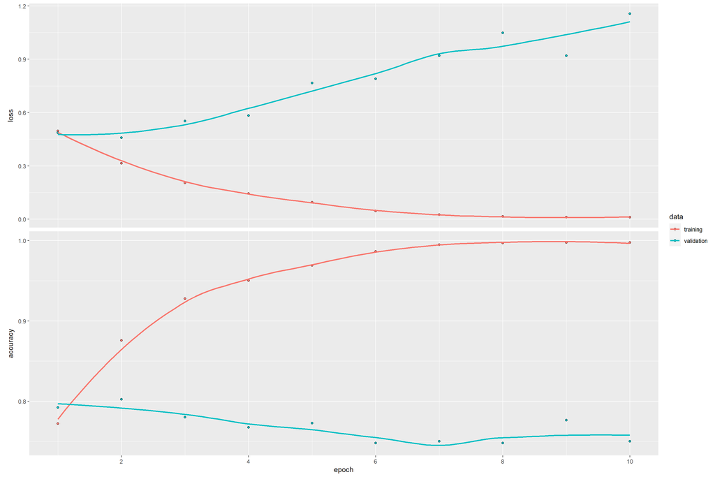

```r
plot(history_rnn)
```

```r
model_rnn1 %>%
  evaluate(x_test, y_test, batch_size = 32) # Lower batch size, as the test data is only a fourth of the training data.
```

```
##     loss accuracy
## 1.156067 0.750000
```

The accuracy is not terrible considering it is a very simple model. It might be interesting to explore how the model predicted, so I will construct a confusion matrix. First, I save a new set of predictions.

```r
pred <- model_rnn1 %>%
  predict(x_test, batch_size = 64) %>%
  round()  # Rounding to closest integer.
```

Then I create a tibble with the true classes and the predictions saved as factors, and create the confidence matrix using *conf_mat* from **yardstick**.

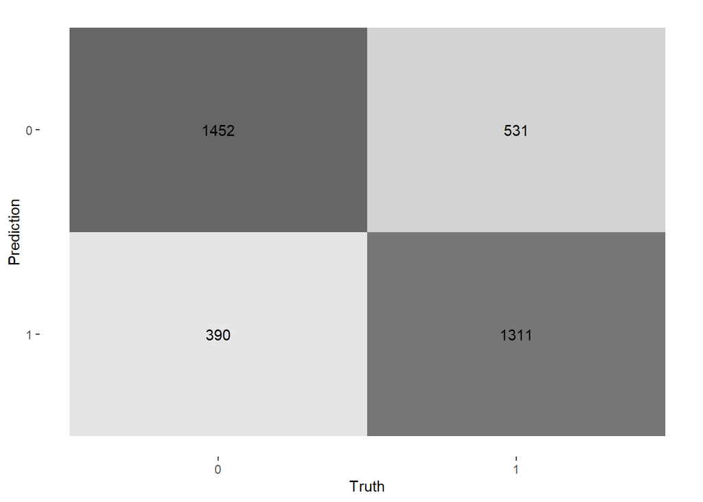

```r
tibble(y_test %>% as.factor(),
       pred %>% as.factor()) %>%
  set_colnames(c("y_test", "pred")) %>% # Renaming the column names so they can easily be called in the following.
  conf_mat(y_test, pred) %>% # Creating the confidence matrix object.
  autoplot(type = "heatmap")
```

The model does pretty well at both classes, but it seems the majority of the mistakes are false negatives. This might stem from some specific things for fake tweets in the training data, that are not generalizable phenomena, seeing how the model is rather overfitted to the training data.

#### RNN Model 2

To combat overfitting I create a deeper neural network where I add dropout layers. These layers add some randomness to the model, as they will randomly drop connections between neurons in the network during iterations. This forces the network to try to learn the same things, with different neurons, which should increase the generalizability of the knowledge. This is also applied after the embedding layer, since it is possible for the model to overfit the training data through the embedding parameters. I also add an additional RNN layer, which will use the output of the first RNN layer as input, after some of the connections are dropped in the dropout layer. Because of this the first layer needs to return sequences of the same length, which is accomplished by using the argument *return_sequences = TRUE*. To reduce overfitting in the second RNN layer I follow it by another dropout layer. I often found that the model performed pretty well in the first iterations, and then did worse and worse on the testing data, so I tried out having the second RNN layer be untrainable, which yielded better results.

```r
model_rnn2 <- keras_model_sequential() %>%
  layer_embedding(input_dim = 6000, output_dim =  32) %>%
  layer_dropout(rate = .3) %>%
  layer_simple_rnn(units = 65, activation = "tanh", return_sequences = TRUE) %>%
  layer_dropout(rate = .8) %>%
  layer_simple_rnn(units = 65, activation = "tanh", trainable = FALSE) %>% # Untrainable RNN layer.
  layer_dense(units = 1, activation = "sigmoid")
```

Let’s inspect the neural network.

```r
summary(model_rnn2)
```

```
## Model: "sequential_1"
## ________________________________________________________________________________
## Layer (type)                        Output Shape                    Param #
## ================================================================================
## embedding_1 (Embedding)             (None, None, 32)                192000
## ________________________________________________________________________________
## dropout (Dropout)                   (None, None, 32)                0
## ________________________________________________________________________________
## simple_rnn_1 (SimpleRNN)            (None, None, 65)                6370
## ________________________________________________________________________________
## dropout_1 (Dropout)                 (None, None, 65)                0
## ________________________________________________________________________________
## simple_rnn_2 (SimpleRNN)            (None, 65)                      8515
## ________________________________________________________________________________
## dense_1 (Dense)                     (None, 1)                       66
## ================================================================================
## Total params: 206,951
## Trainable params: 198,436
## Non-trainable params: 8,515
## ________________________________________________________________________________
```

Everything seems to be in order. There are 206,951 weights or biases to be estimated and 198,436 trainable parameters. Next I compile and fit the model. I adjusted the number of epochs and the layer dropout rates, through trial and error, to find the settings that seemed to yield the highest accuracy and overfit the least.

```r
set.seed(1337)
model_rnn2 %>% compile(optimizer = "adam",
                      loss = "binary_crossentropy",
                      metrics = "accuracy")

history_rnn2 <- model_rnn2 %>% fit(
  x_train, y_train,
  epochs = 5,
  batch_size = 256,
  validation_data = list(x_test, y_test),
  verbose = 2)
```

Let’s see how the model did.

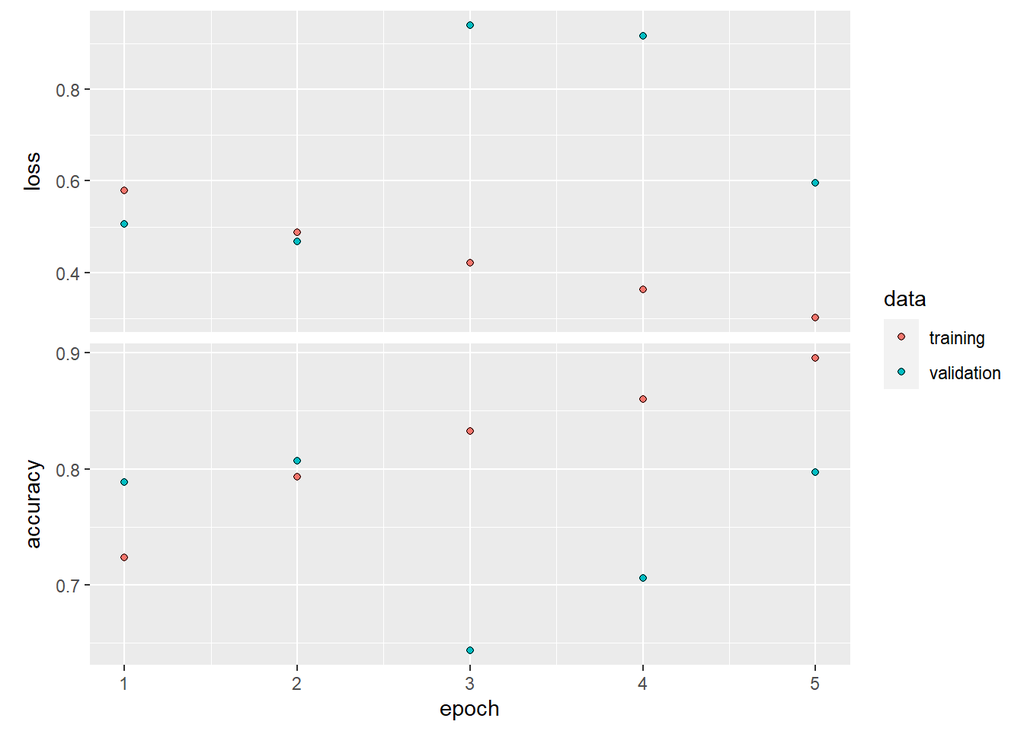

```r
plot(history_rnn2)
```

Compared to epoch 5 of the previous model, the overfitting has been reduced a bit, and the spread between the training and validation accuracies has been reduced. The model continues towards just shy of 100% training accuracy, but it takes more epochs than before.

```r
model_rnn2 %>% evaluate(x_test, y_test, batch_size = 32)
```

```
##      loss  accuracy
## 0.5956945 0.7972313
```

The final model ended up having an accuracy of almost 80%. To see how the predictions were distributed, I create another confusion matrix.

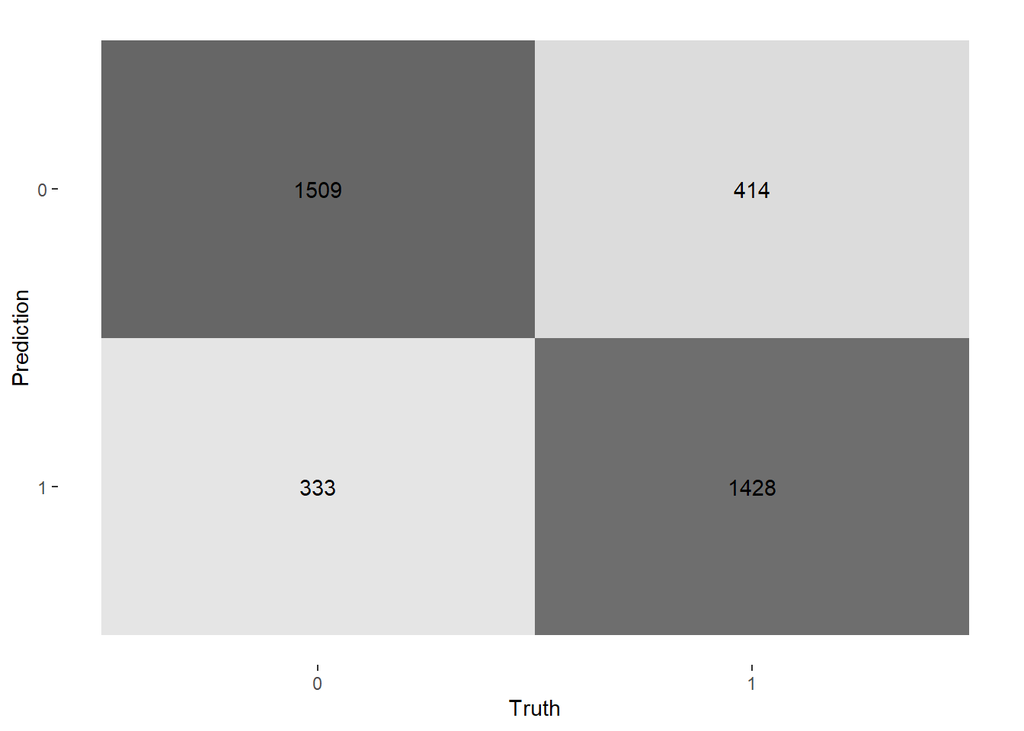

```r
pred2 <- model_rnn2 %>%
  predict(x_test, batch_size = 64) %>%
  round()

results_rnn2 <- tibble(y_test %>% as.factor(),
                       pred2 %>% as.factor()) %>%
  set_colnames(c("y_test", "pred_rnn2"))
results_rnn2 %>%
  conf_mat(y_test, pred_rnn2) %>%
  autoplot(type = "heatmap")
```

It seems most of the improved accuracy stems from less false negatives. Overall the model did fairly well, but I would like to see if an LSTM could yield a better result.

### LSTM

A long short-term memory neural network is a special variant of an RNN layer, which can carry information unchanged over many timesteps, or in our case, always try to remember the relevant words in a sequence. This becomes important when working with longer timeframes, or longer text sequences. LSTM might be a bit overkill considering the longest tweet consists of 65 words, however perhaps it is particularly the longer tweets that the flaws of the AI generated tweets become apparent.

For my model I opt for a similar embedding layer followed by a dropout layer to prevent overfitting. After this I add my LSTM layer with 65 units, which I specify to not return sequences, as the output will go directly to my dense layer, to predict a final class. I tried having multiple LSTM layers, but this made the overfitting in the model worse, and resulted in lower testing accuracy.

```r
set.seed(1337)
model_lstm <- keras_model_sequential() %>%
  layer_embedding(input_dim = 6000, output_dim = 32) %>%
  layer_dropout(rate = 0.3) %>%
  layer_lstm(units = 65, dropout = 0.4, return_sequences = FALSE) %>%
  layer_dense(units = 1, activation = "sigmoid")

model_lstm %>% compile(
  optimizer = "adam",
  loss = "binary_crossentropy",
  metrics = "accuracy"
)
```

Let’s see if everything is in order.

```r
summary(model_lstm)
```

```
## Model: "sequential_2"
## ________________________________________________________________________________
## Layer (type)                        Output Shape                    Param #
## ================================================================================
## embedding_2 (Embedding)             (None, None, 32)                192000
## ________________________________________________________________________________
## dropout_2 (Dropout)                 (None, None, 32)                0
## ________________________________________________________________________________
## lstm (LSTM)                         (None, 65)                      25480
## ________________________________________________________________________________
## dense_2 (Dense)                     (None, 1)                       66
## ================================================================================
## Total params: 217,546
## Trainable params: 217,546
## Non-trainable params: 0
## ________________________________________________________________________________
```

The model looks good to go. To once and for all combat overfitting, I specify the argument *callback_early_stopping* to stop training if the validation loss has not improved since the previous epoch. Furthermore I specify that the model must restore the weights that yielded the lowest validation loss, if it is stopped before running through all epochs. I tried to apply this to the previous model, but it performed better by just having fewer epochs as input.

```r
set.seed(1337)
history_lstm <- model_lstm %>% fit(
  x_train,
  y_train,
  epochs = 10,
  batch_size = 128,
  validation_data = list(x_test, y_test),
  verbose = 2,
  callback_early_stopping(monitor = "val_loss", restore_best_weights = TRUE)
  )
history_lstm
```

```
##
## Final epoch (plot to see history):
##         loss: 0.2911
##     accuracy: 0.8824
##     val_loss: 0.4335
## val_accuracy: 0.8089
```

The model stops improving after it’s second epoch, and therefore stops it’s training. Let’s check the final model accuracy on the testing data:

```r
model_lstm %>% evaluate(x_test, y_test, batch_size = 32)
```

```
##      loss  accuracy
## 0.4233084 0.8135179
```

Because of restoring the best previous weights, the model has an accuracy of 81%. Let’s see how the model predicted.

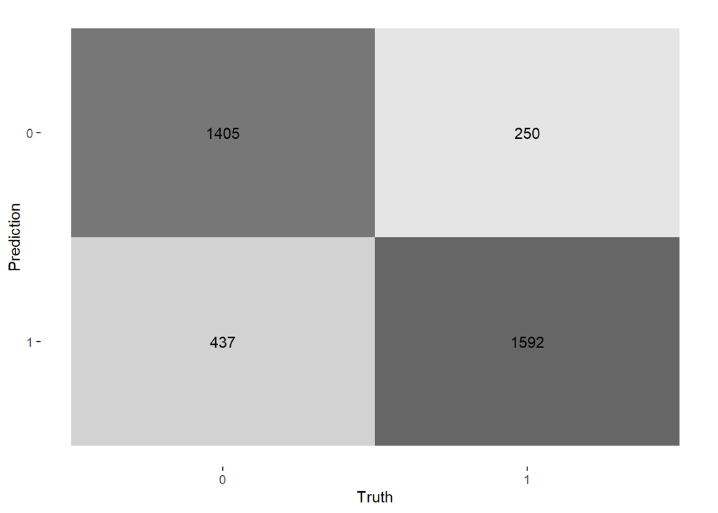

```r
pred3 <- model_lstm %>%
  predict(x_test, batch_size = 64) %>%
  round()

results_lstm <- tibble(y_test %>% as.factor(),
                       pred3 %>% as.factor()) %>%
  set_colnames(c("y_test", "pred_lstm"))

results_lstm %>%
  conf_mat(y_test, pred_lstm) %>%
  autoplot(type = "heatmap")
```

### Prediction evaluation

To finish my analysis I want to inspect what went wrong, when the models predicted wrong. To do this I need to find the tweets where this happened. I find the tweets that were predicted wrong by model *lstm*, but right by model *rnn2* and vice versa.

```r
agg_results <- results_rnn2 %>%
  cbind(results_lstm[,2]) %>% # Adding the column of results from the LSTM to the results of rnn2
  mutate(id = row_number()) # Adding a column of row numbers, to locate tweets later.

rnn_acc <- agg_results %>%
  filter(y_test == pred_rnn2 & y_test != pred_lstm) # Cases where rnn2 prediction is correct and lstm prediction is not.
lstm_acc <- agg_results %>%
  filter(y_test == pred_lstm & y_test != pred_rnn2) # Cases where lstm prediction is correct and rnn2 prediction is not.
```

```r
lstm_acc$y_test %>% summary()
```

```
##   0   1
##  46 193
```

```r
rnn_acc$y_test %>% summary()
```

```
##   0   1
## 150  29
```

Clearly, the LSTM model comparatively had difficulties with the fake tweets, which also makes the RNN more appealing, since it is better at detecting the fake tweets. Perhaps this is a result of the LSTM model training ending before all epochs were completed, and the model not seeing enough iterations of the training data.